# Laboratory 1

Simulation, examples and exercises

Gioia Di Credico

Spring 2020

# Before starting

Along the course, we will need specific packages and libraries. You may install a package simply typing in your console the command:

$\mathsf{install.packages("name\_package")}$

and then load in your environment with the function

$\mathsf{library("name\_package")}$

We will often use the package related to the book *Data Analysis and Graphics Using R*, written by John Maindonald and W.John Braun.

The package of the book is called $\mathsf{DAAG}$ and you may install and load in your laptop.

# $\mathsf{R}$: basic commands and assignments

## Vectors

The typical command for defining a vector in $\mathsf{R}$ is $\mathsf{c()}$. Let see some examples of vectors:

```r
c(2,5,6,4,5)
```

```
## [1] 2 5 6 4 5
```

```r
c("Roma", "Milano", "Trieste")
```

```
## [1] "Roma"    "Milano"  "Trieste"
```

```r
c(T, F,T,T,F)
```

```
## [1]  TRUE FALSE  TRUE  TRUE FALSE
```

```r
#standard way for storing a vector, with <- assignment
x <- c( 0.2, 0.4, 0.5, 0.6)
```

There are various functions for inspecting the vectors and other $\mathsf{R}$ objects:

```r
# the vector length
length(x)
```

```
## [1] 4
```

```r
# test the condition of"greater than"
x > 0.5
```

```
## [1] FALSE FALSE FALSE  TRUE
```

```r
# test the condition "not"
x != 0.2
```

```
## [1] FALSE  TRUE  TRUE  TRUE
```

For accessing the element vectors, the rule is to use the square brackets:

```r
# extract the first element of the vector
x[1]
```

```
## [1] 0.2
```

```r
# extract the first two items of the vector
x[c(1,2)]
```

```
## [1] 0.2 0.4
```

```r
# omit the first two items of the vector
x[-c(1,2)]
```

```
## [1] 0.5 0.6
```

```r
# extract given a condition
x[ x > 0.5 ]
```

```
## [1] 0.6
```

```r
# concatenate vectors
y <- c(1,3,5,7)
z <- c(x,y)
z
```

```
## [1] 0.2 0.4 0.5 0.6 1.0 3.0 5.0 7.0
```

```r
w<-(x+y)^2
w
```

```
## [1]  1.44 11.56 30.25 57.76
```

There are two widely used functions for dealing with vectors, other than $\mathsf{c()}$: $\mathsf{seq(), rep()}$.

```r
seq(from=4, to=8, by=0.5)
```

```
## [1] 4.0 4.5 5.0 5.5 6.0 6.5 7.0 7.5 8.0
```

```r
seq(from=4, to=8, length.out=9)
```

```
## [1] 4.0 4.5 5.0 5.5 6.0 6.5 7.0 7.5 8.0
```

```r
rep(c("Bello", "Brutto"), 4)
```

```
## [1] "Bello"  "Brutto" "Bello"  "Brutto" "Bello"  "Brutto" "Bello"  "Brutto"
```

```r
c(rep("Data scientists",1), rep("are crazy",1))
```

```
## [1] "Data scientists" "are crazy"
```

## Matrices

Defining a matrix is slightly more complicate than defining a vector, since this requires the determination of the number of rows and the number of columns in advance. This is made possible by the function $\mathsf{matrix()}$.

```r
# define a matrix of 1 values with 3 rows and 5 columns
mat<-matrix(1, nrow=3, ncol=5)
mat
```

```
##      [,1] [,2] [,3] [,4] [,5]
## [1,]    1    1    1    1    1
## [2,]    1    1    1    1    1
## [3,]    1    1    1    1    1
```

```r
# define a matrix where each row cell represents the row number
mat2<-matrix( c(rep(1,5), rep(2,5), rep(3,5)   ),nrow=3,ncol=5, byrow=TRUE)
mat2
```

```
##      [,1] [,2] [,3] [,4] [,5]
## [1,]    1    1    1    1    1
## [2,]    2    2    2    2    2
## [3,]    3    3    3    3    3
```

```r
# concatenate matrices
mat_conc<-rbind(mat, mat2)
# dimension of the matrix
dim(mat_conc)
```

```
## [1] 6 5
```

```r
mat_conc
```

```
##      [,1] [,2] [,3] [,4] [,5]
## [1,]    1    1    1    1    1
## [2,]    1    1    1    1    1
## [3,]    1    1    1    1    1
## [4,]    1    1    1    1    1
## [5,]    2    2    2    2    2
## [6,]    3    3    3    3    3
```

```r
# extract the first columns of the matrix
mat_conc[,1]
```

```
## [1] 1 1 1 1 2 3
```

```r
# extract the first row of the matrix
mat_conc[1,]
```

```
## [1] 1 1 1 1 1
```

One of the most useful $\mathsf{R}$ functions is $\mathsf{apply()}$, suitable for computing some quantities:

```r
# compute the total sum of each row
apply(mat_conc,1, sum)
```

```
## [1]  5  5  5  5 10 15
```

```r
# compute the mean of each row
apply(mat_conc,1, mean)
```

```
## [1] 1 1 1 1 2 3
```

```r
# compute the total sum of each column
apply(mat_conc,2, sum)
```

```
## [1] 9 9 9 9 9
```

The matrix product in $\mathsf{R}$ is performed via the command ’%*%’:

```r
mat%*%t(mat2)
```

```
##      [,1] [,2] [,3]
## [1,]    5   10   15
## [2,]    5   10   15
## [3,]    5   10   15
```

## Data frames

Generally, data scientists and statisticians need to work with well organized sets of data, also called *data frames*. In $\mathsf{R}$ the $\mathsf{data.frame()}$ function allows for dealing with these data structures. Suppose to have the totals of carbon emissions that resulted from fossil fuel use. We may preliminary plot the two variables and then collect them in a data frame.

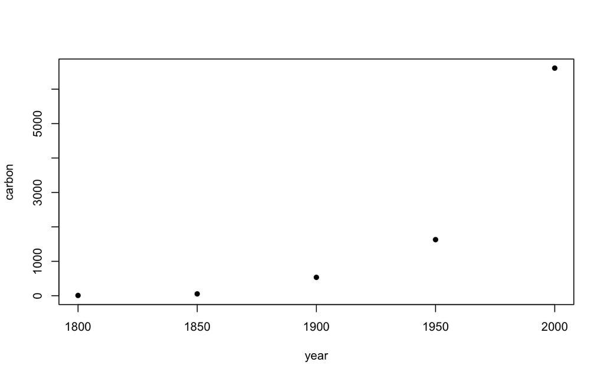

```r
year<-c(1800, 1850, 1900, 1950, 2000)
carbon<-c(8, 54, 534, 1630, 6611)
plot(carbon~year, pch=16)
```

```r
fossil_frame<-data.frame(year=year, carbon=carbon)
fossil_frame
```

```
##   year carbon
## 1 1800      8
## 2 1850     54
## 3 1900    534
## 4 1950   1630
## 5 2000   6611
```

Many datasets are available in some $\mathsf{R}$ packages, and many others are already available in $\mathsf{R}$, with no need to install the packages. For instance, the dataset $\mathsf{cars}$ contains the speed in mph and the stopping distance of 50 cars. (For more details, type $\mathsf{help(cars)}$ on your $\mathsf{R}$ console.)

```r
# with this function I access general information about the dataset
summary(cars)
```

```
##      speed           dist
##  Min.   : 4.0   Min.   :  2.00
##  1st Qu.:12.0   1st Qu.: 26.00
##  Median :15.0   Median : 36.00
##  Mean   :15.4   Mean   : 42.98
##  3rd Qu.:19.0   3rd Qu.: 56.00
##  Max.   :25.0   Max.   :120.00
```

```r
is.data.frame(cars)
```

```
## [1] TRUE
```

```r
# display the first 5 items
head(cars, n=5)
```

```
##   speed dist
## 1     4    2
## 2     4   10
## 3     7    4
## 4     7   22
## 5     8   16
```

```r
# extract column names
colnames(cars)
```

```
## [1] "speed" "dist"
```

Accessing the elements of a data frame is easy. Analogously to what we did with the matrices, we may use the square brackets:

```r
# extract the first five rows
cars[1:5,]
```

```
##   speed dist
## 1     4    2
## 2     4   10
## 3     7    4
## 4     7   22
## 5     8   16
```

```r
# extract the first five rows and the first column
cars[1:5,]
```

```
##   speed dist
## 1     4    2
## 2     4   10
## 3     7    4
## 4     7   22
## 5     8   16
```

An elegant way for accessing the elements of a data frame, given a particular condition, is made possible by the use of the function $\mathsf{subset()}$:

```r
# extract the units with a speed greater than 50 mph
subset(cars, speed>20)
```

```
##    speed dist
## 44    22   66
## 45    23   54
## 46    24   70
## 47    24   92
## 48    24   93
## 49    24  120
## 50    25   85
```

```r
# extract the units with the dist minor than 10 or greater than 25
subset(cars, dist<10 | dist>75)
```

```
##    speed dist
## 1      4    2
## 3      7    4
## 23    14   80
## 34    18   76
## 35    18   84
## 47    24   92
## 48    24   93
## 49    24  120
## 50    25   85
```

## Functions for importing a data frame

In the majority of the cases, datasets are *external* with respect to the $\mathsf{R}$ environment and owned/collected by the researchers. In such cases, we need specific functions for importing the dataset, $\mathsf{R}$ provides a flexible set of commands for importing the data.

```r
# for .txt files

studenti <- read.table( file="file_text.txt", header=TRUE, sep="", dec=".")
studenti
```

```
##   studente voto esame_precedente
## 1    Chris   23               24
## 2    Evans   25               23
## 3   Martin   27               22
## 4   Dudley   23               30
```

```r
# for .csv files
teams <- read.csv(file="file_excel.csv", header=TRUE, sep=";")
teams
```

```
##    home.team   away.team goals.home goal.away shots.home shots.away
## 1  Liverpool     Watford          4         2          7          7
## 2   Chelsea  Southampton          1         1         10          9
## 3 Man United     Burnley          2         1         10          4
## 4   Man City     Arsenal          3         0         12          5
```

For accessing the columns (variables) of your dataframe, yoy may use the $:

```r
# for .txt files
studenti$voto
```

```
## [1] 23 25 27 23
```

```r
teams$shots.home
```

```
## [1]  7 10 10 12
```

## If statement

Analogously to other languages, $\mathsf{R}$ allows for testing some conditions with $\mathsf{if,\ldots,else, \ldots else\ if}$ statements.

```r
s <- c(20,30,45,30, 34)

if (mean(s)<=20){
  print("mean is minor than 20")
}else if(mean(s)>20 & mean(s)>=30){
  print("mean is bounded between 20 and 30")
}else{
  print("mean is greater than 30")
}
```

```
## [1] "mean is bounded between 20 and 30"
```

## Loops

Loops are easily doable in $\mathsf{R}$. Suppose to build the first 20 elements of the Fibonacci sequence:

```r
n<-20
fibonacci_seq<-c()
fibonacci_seq[1]<-1
fibonacci_seq[2]<-1
for (i in 3: n){
  fibonacci_seq[i] <- fibonacci_seq[i-2]+fibonacci_seq[i-1]
}
fibonacci_seq
```

```
##  [1]    1    1    2    3    5    8   13   21   34   55   89  144  233  377  610
## [16]  987 1597 2584 4181 6765
```

## Writing your own function

$\mathsf{R}$ contains a lot of built-in functions. However, sometimes you could need to write your own function, depending on some parameters/input values, in order to obtain some output values.

```r
# generic function syntax
foo <- function(param1, param2){
  output=f(param1, param2)
return(output)
}
```

For instance, you may write a mathematical function:

```r
parabola <- function(x,a,b,k){
 y=a*x^{2}+b*x+k
return(y)
}
parabola(2,-2,3,1)
```

```
## [1] -1
```

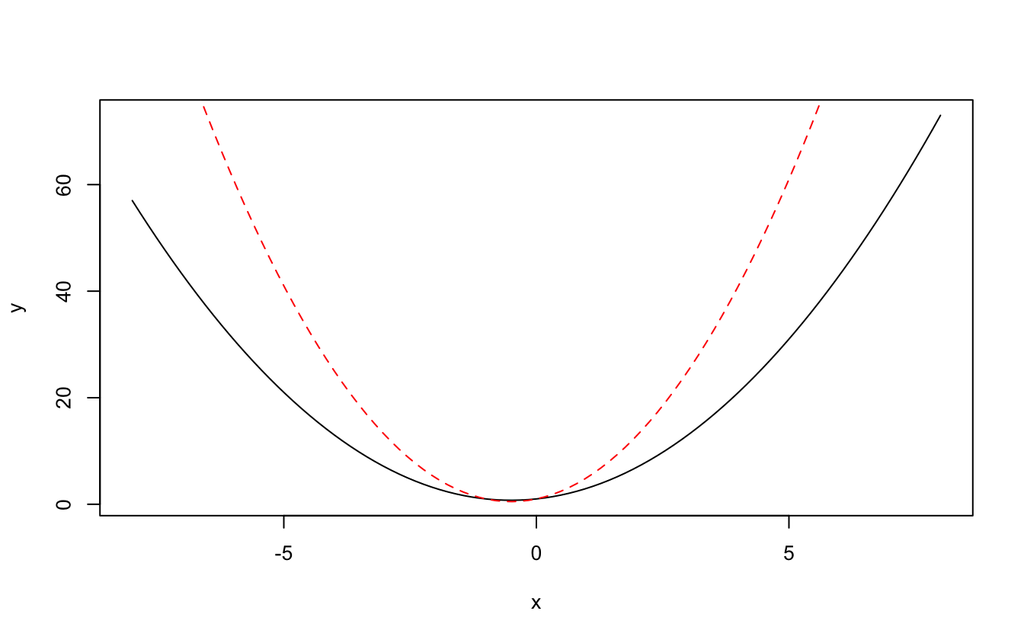

```r
curve(parabola(x, a=1, b=1, k=1), xlim=c(-8,8), ylab="y")
curve(parabola(x, a=2, b=2, k=1), xlim=c(-8,8),col="red", lty=2, ylab="y", add=TRUE)
```

# $\mathsf{R}$ statistical introduction: probability distributions

## Some useful commands for the distributions

For the main discrete and continuous distributions, $\mathsf{R}$ provides some built-in functions for computing the density/probability function, the cumulative distribution function, the quantile function and the random generation of random numbers. The syntax is the following:

- $\mathsf{d<name>(x,<parameters>)}$ density (probability) function in $x$.
- $\mathsf{p<name>(x,<parameters>)}$ cumulative distribution function in $x$.
- $\mathsf{q<name>(r,<parameters>)}$ $r$-th quantile.
- $\mathsf{r<name>(n,<parameters>)}$ generation of $n$ random numbers.

Some examples:

```r
#Compute the density of a normal(0,1) in 1.96
dnorm(1.96)
```

```
## [1] 0.05844094
```

## Examples

```r
set.seed(1)
#Compute the density of a normal(1,2) in 1.96
dnorm(1.96, mean=1, sd=sqrt(2))
```

```
## [1] 0.2240442
```

```r
#Compute the distribution function of a gamma(2,2) in 1
pgamma(1,shape=2, rate=2, lower.tail=TRUE)
```

```
## [1] 0.5939942
```

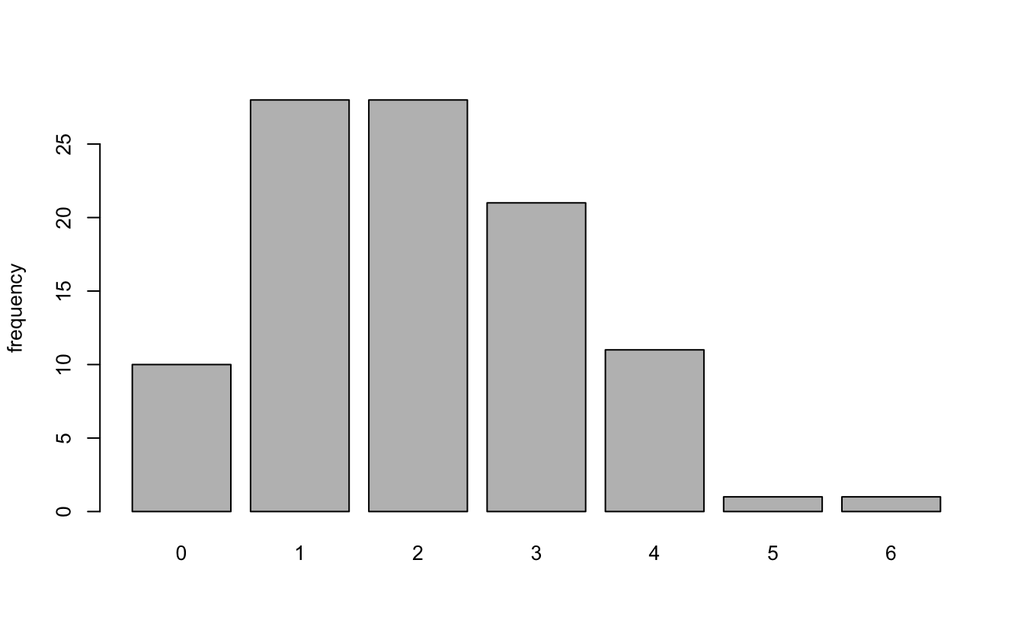

```r
#generate 100 values from a Poisson distribution with
#rate 2 and plot the correspondent histogram
z<-rpois(100,2)
barplot(table(z), ylab="frequency")
```

# Discrete random variables

## The binomial distribution

Consider $n$ independent binary trials each with success probability $p$, $0 < p < 1$. The r.v. $X$ that counts the number of successes has **binomial distribution** with probability function
$${\rm Pr}(X = x) = \binom{n}{x} p^x \, (1-p)^{n-x} \, , \hspace{1cm} x = 0,\ldots,n\, .$$

The notation is $X \sim {\cal B}_i(n, p)$, and $E(X) = n\,p$, ${\rm Var}(X) = n\,p\,(1-p)$.

The case when $n = 1$ is known as **Bernoulli distribution**.

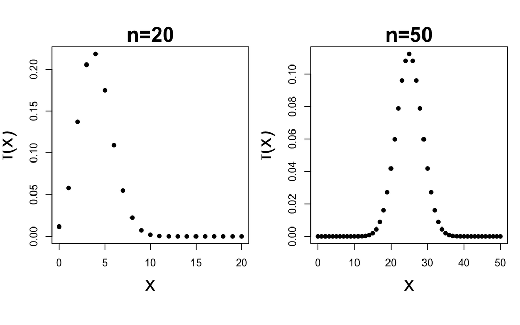

```r
#graphical setting for margins and type of points
par(mfrow=c(1,2),mar=c(5,4,2,1), oma=c(0,0.2,0.2,0), pty="s", pch = 16)
#plot the binomial distributions with different input
plot(0:20, dbinom(0:20, 20, 0.2),
     xlab = "x", ylab = "f(x)", cex.lab=2, main="n=20", cex.main=2)
plot(0:50, dbinom(0:50, 50, 0.5), xlab ="x", ylab = "f(x)",
      cex.lab=2, main= "n=50", cex.main=2)
```

## The binomial distribution: genesis

Let $X_{1}, \ldots, X_{n}$ denote i.i.d r.v, where each $X_{i}$ is an independent binary trial each with success probability $p$. In symbols,

$$X_{i}= \begin{cases}
1 & \mbox{ with probability } p \\
0 & \mbox{ with probability } 1-p
\end{cases}$$

The single trial is a Bernoulli distribution with mean $p$ and variance $p(1-p)$.

The sum of these r.v., $n\overline{X}_{n}=\sum_{i=1}^{n}X_{i}$, follows a Binomial distribution with mean $np$ and variance $np(1-p)$.

**Exercise 1**

- Write a function $\mathsf{binomial(x,n,p)}$ for the binomial distribution above, depending on parameters $\mathsf{x,n,p}$, and test it with some prespecified values. Use the function $\mathsf{choose()}$ for the binomial coefficient.
- Plot two binomials with $n=20$, and $p=0.3, 0.6$ respectively.

## The geometric distribution

The geometric distribution is used for modeling the number of failures until the first success:

$$Pr(X=r)=p(1-p)^{r}, \ r=0,1,2,\ldots$$

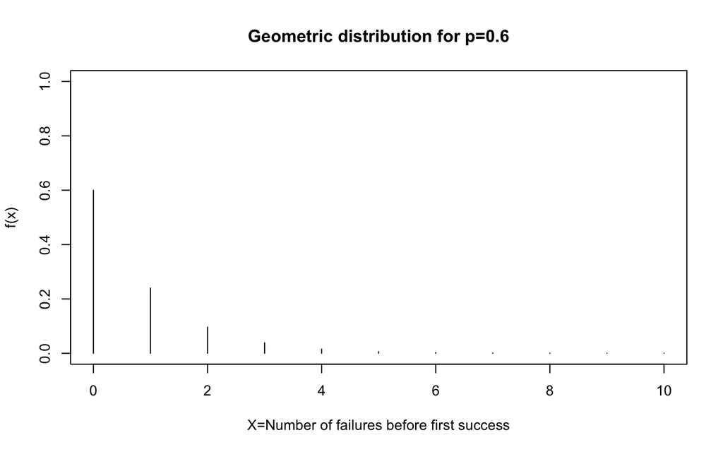

```r
X=0:10
# use dgeom(x,p), with x number of failures and probability of success p
plot(X, dgeom(X,0.6), type="h", ylim=c(0,1), main="Geometric distribution for p=0.6", ylab="f(x)", xlab="X=Number of failures before first success")
```

If $X_{1}, \ldots, X_{k}$ are independent geometrically distributed variables with parameter p, then the sum $n\overline{X}_{n}=\sum_{i=1}^{k} X_{i}$ follows a **negative binomial distribution**, $NB_i(k,p)$. Denoting $Y=n\overline{X}_{n}$, the probability function is:

$$Pr(Y=r)= \binom{k+r-1}{k}p^{k}(1-p)^r,$$

where $k$ is a predefined number of successes. The above distribution expresses the probability of observing $r$ failures before a prespecified number of $k$ successes, and has mean $E(Y)=k\frac{(1-p)}{p}$ and variance $Var(Y)=k\frac{(1-p)}{p^{2}}$.

## The negative-binomial: Mini Cooper example

Suppose we are looking out from the window, and we want to count the number of Mini Cooper (our successes), let’s say the first three of them. How many trials do we have to wait before the k-th success? Assume that the probability of observing a Mini Cooper is $p=0.08$.

Y = number of cars other than Mini Cooper

$k=3$, number of successes (**prespecified**).

$r=$ number of failures (**random**)

Which is the probability of observing exactly 20 other cars before observing 3 Mini Cooper? Solve in $\mathsf{R}$.

```r
k<-3;r<-20; p<-0.08;
dnbinom(x=r, size=k,prob=p )
```

```
## [1] 0.02231714
```

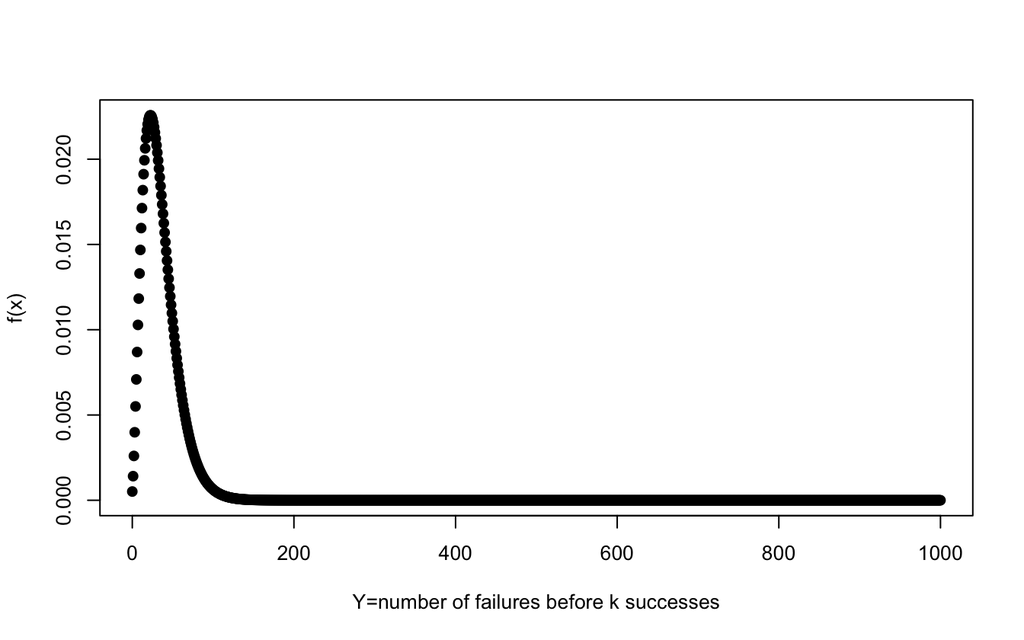

```r
plot(0:1000, dnbinom(0:1000, size=k, prob=p), xlab="Y=number of failures before k successes",
  ylab="f(x)",pch=21, bg=1)
```

**Exercise 2**

- Generate in $\mathsf{R}$ the same output, but using $\mathsf{rgeom()}$ for generating the random variables. *Hint*: generate $n$ times three geometric distribution $X_1,\ldots, X_3$ with $p=0.08$, store them in a matrix and compute then the sum $Y$.

## The Poisson distribution

The Poisson distribution is used for modelling counts:

$$Pr(X=x)=\frac{e^{-\lambda} \lambda^{x}}{x!}, \ x=0,1,2,\ldots; \ \ \ \ \lambda>0.$$
For this distribution, $E(X)={\rm Var}(X)=\lambda$.

# Continuous random variables

## Gamma distribution

The **Gamma** distribution is a two-parameter family of continuous distribution: the **Exponential** and the $\chi^{2}$ distribution are special cases of the Gamma distribution. The density for a $\mbox{Gamma}(\alpha, \beta)$ is:

$$f(x; \alpha, \beta)= \frac{\beta^{\alpha} }{\Gamma(\alpha)}e^{-\beta x}x^{\alpha-1}, \ \ \alpha, \beta >0, \ x \in (0, \infty),$$
where $\alpha$ is the *shape* parameter and $\beta$ the *rate* parameter.

Let’s investigate the relationships with the other mentioned distribution through $\mathsf{R}$ simulation. Here we consider $X_1, \ldots, X_n \sim Exp(\beta)$. What is the distribution of $Y= \sum_{i=1}^{n} X_i$?

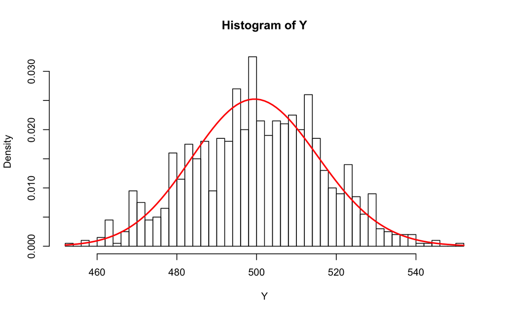

```r
n<-1000; alpha<-2; beta<-2; sample_rep<-1000
X<-matrix(NA, n, sample_rep)
for (h in 1:n){
  X[h,]<-rexp(sample_rep, beta)
}
Y<-apply(X,1,sum)
hist(Y, breaks=40, probability=TRUE)
curve(dgamma(x, n, beta), col="red", lwd=2, add=TRUE)
```

Thus, the exponential distribution $\mbox{Exp}(\beta)$ is a special case of a Gamma, precisely $\mbox{Gamma}(1, \beta)$.

**Exercise 3**

- Show in $\mathsf{R}$, also graphically, that $\mbox{Gamma}(n/2, 1/2)$ coincides with a $\chi^{2}_{n}$.
- Find the 5% and the 95% quantiles of a $\mbox{Gamma}(3,3)$.

## Beta distribution

In probability and statistics, proportions are widely studied. Thus, researchers often need to work with a distribution function *bounded* in $[0,1]$. This is the case of the **Beta** distribution, $\mbox{Beta}(\alpha, \beta)$, with density function:

$$f(x; \alpha, \beta)=\frac{1}{B(\alpha, \beta)}x^{\alpha-1}(1-x)^{\beta-1}, \ x \in [0,1], \ \alpha, \beta >0,$$

where $B(\alpha, \beta)=\frac{\Gamma(\alpha) \Gamma(\beta)}{\Gamma(\alpha+\beta)}$ is the so called Beta function, which is a normalization constant to ensure that the total probability integrates to 1.

From probabiliy theory we know that;

$$\begin{align*}
E(X)=&\int_{0}^{1}xf(x;\alpha,\beta)dx=\frac{\alpha}{\alpha+\beta} \\
Var(X)=& \int_{0}^{1} (x-E(X))^{2} f(x;\alpha,\beta)dx=\frac{\alpha \beta}{(\alpha+\beta)^2(\alpha+\beta+1)}
\end{align*}$$

**Exercise 4**

- Generate $n=1000$ values from a $\mbox{Beta}(5,2)$ and compute the sample mean and the sample variance.

## The mixture distribution

In statistics, the mixture distribution entails the concepts of conditional and marginal distribution. If $X|Y \sim g_{X|Y}(\cdot)$, and $Y \sim h_Y(\cdot)$, then the marginal distribution for $X$ is a **mixture distribution** with form:

$$f(x)= \int_{\mathcal{Y}} g_{X|Y}(\cdot)h_{Y}(\cdot)dy$$

For instance, given $X|Y \sim \mbox{Normal}(0, 1/\sqrt{Y}), Y \sim \mbox{Gamma}(\nu/2, \nu/2)$, one can prove that the $X \sim t_{\nu}$, where $t_{\nu}$ is a **Student’s t distribution** with $\nu$ degrees of freedom. Let’s investigate via simulation.

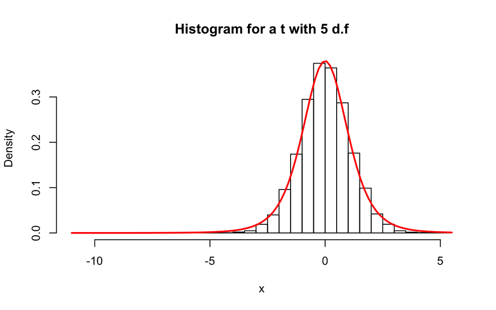

```r
t_mixture <- function(mean,  df, n){

  Z=rgamma(n, df/2, df/2)
  X=rnorm(n, mean, sd=sqrt(1/sqrt(Z)))
  return(X)

}
df<-5
hist(t_mixture(0,df,10000), probability=TRUE, breaks=40,
  main=paste("Histogram for a t with", df, "d.f"), xlab="x")
curve(  dt(x,5), col="red", lwd=2, add=TRUE )
```

**Exercise 5**

- Analogously, show with a simple $\mathsf{R}$ function that a negative binomial distribution may be seen as a mixture between a Poisson and a Gamma. In symbols: $X|Y \sim \mathcal{P}(Y)$, $Y \sim \mbox{Gamma}(\alpha, \beta)$, then $X \sim \ldots$.

# Statistical applications

## The empirical distribution function

We know that the **empirical cumulative distribution function** is defined as:

$$\widehat{F}_n(t) = \dfrac{\text{number of elements of $y$}\leq t}{n} \,.$$

Under some mild conditions, $\widehat{F}_n(t)$ converges to the true cumulative distribution function $F(x)$. Suppose to generate $n$ values from a $\mbox{Beta}(3,4)$ and use the $\mathsf{ecdf()}$ function.

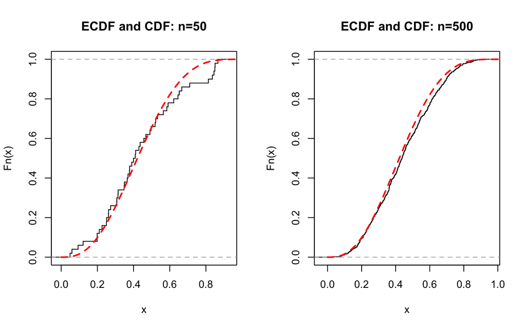

```r
set.seed(2)
par(mfrow=c(1,2))
n<-50
y<-rbeta(n, 3,4)
edf_beta<-ecdf(y)
tt<-seq(from=0, to=1, by=0.01)
plot(edf_beta, verticals=TRUE, do.p=FALSE, main="ECDF and CDF: n=50")
lines(tt, pbeta(tt,3,4), col=2, lty=2, lwd=2)
n2<-500
y2<-rbeta(n2, 3,4)
edf_beta2<-ecdf(y2)
tt<-seq(from=0, to=1, by=0.01)
plot(edf_beta2, verticals=TRUE, do.p=FALSE, main="ECDF and CDF: n=500")
lines(tt, pbeta(tt,3,4), col=2, lty=2, lwd=2)
```

As $n \rightarrow \infty$, the approximation to the true $F$ improves.

**Exercise 6**

- Instead of using the built-in function $\mathsf{ecdf()}$, write your own $\mathsf{R}$ function for the empirical cumulative distribution function and reproduce the two plots above.

## The empirical distribution function and the quantiles

Another way for comparing the empirical distribution with the true distribution is the *quantile-quantile plot*. We already know that the quantile function $\mathsf{q<name>(p,)}$ is the inverse of the cdf function $\mathsf{p<name>(q,)}$. In the previous example, we may compare directly the quantiles via the $\mathsf{qqplot()}$ graphical function. This is a useful tool for assessing the plausibility of a theoretical distribution for a set of observations $y = (y_1, . . . , y_n)$.

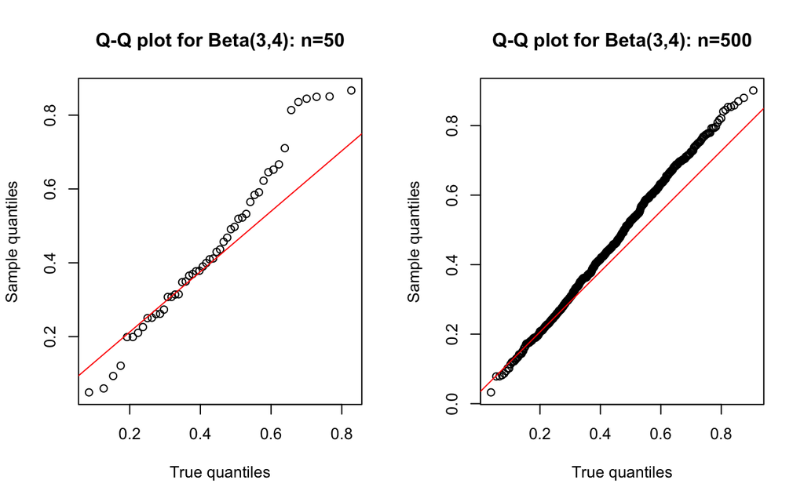

```r
par(mfrow=c(1,2))
qqplot(qbeta(ppoints(n),3,4),y,
  xlab="True quantiles", ylab="Sample quantiles",
  main = "Q-Q plot for Beta(3,4): n=50")
qqline(y, distribution = function(p) qbeta(p, 3,4),
       prob = c(0, 1), col = 2)

qqplot(qbeta(ppoints(n2),3,4),y2,
  xlab="True quantiles", ylab="Sample quantiles",
  main = "Q-Q plot for Beta(3,4): n=500")
qqline(y2, distribution = function(p) qbeta(p, 3,4),
       prob = c(0, 1), col = 2)
```

The quantile-quantile plot is a powerful test for assessing the **model goodness-of-fit**, and more specifically the normality assumption.

**Exercise 7**

Compare in $\mathsf{R}$ the assumption of normality for these samples:

- $y_1, \ldots, y_{100} \sim t_{\nu},$ with $\nu=5,20, 100$. What does it happens when the number of degrees of freedom $\nu$ increases?
- $y_1, \ldots, y_{100} \sim \mbox{Cauchy}(0,1)$. Do you note something weird for the extremes quantiles?

## The binomial distribution: approximation with CLT

Using the **central limit theorem**, we may approximate the binomial distribution with a normal distribution. In fact, by means of CLT, we already know that
$$\overline{X}_n \sim {\cal N}(p, p(1-p)/n) \, .$$
Then, it is easy to show that

$$n \overline{X}_n \sim {\cal N}(np, np(1-p)) \, .$$
For large $n$, the binomial distribution may be approximated by a normal distribution with mean $\mu=np$ and variance $\sigma^{2}=np(1-p)$.

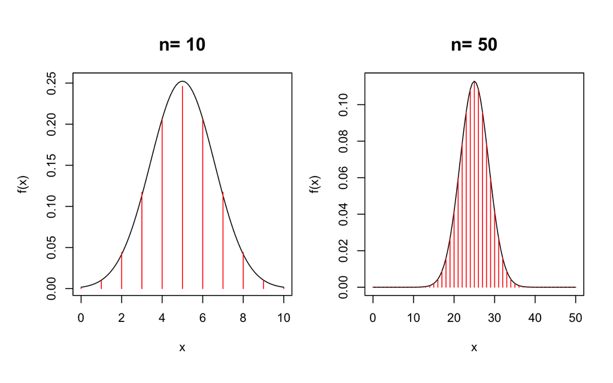

```r
#set the seed
set.seed(123)
par(mfrow=c(1,2), mar=c(5,4,4,1), oma=c(1,1,1,1))
p<-0.5; size1<-10; size2<-50
#normal approximation
prob_bin <- dbinom(0:size1, size1,p)
curve(dnorm(x, size1*p, sqrt(size1*p*(1-p))), xlim=c(0,size1),
      xlab="x", ylab="f(x)",
  main=paste("n=", size1), cex.main=1.5)
lines(0:size1,prob_bin, type="h", main="n=10", xlim=c(0,size1),
     cex.lab=1.5, col="red")

prob_bin <- dbinom(0:size2, size2,p)
curve(dnorm(x, size2*p, sqrt(size2*p*(1-p))), xlim=c(0,size2),
      xlab="x", ylab="f(x)", main=paste("n=", size2), cex.main=1.5)
lines(0:size2,prob_bin, type="h", main="n=10", xlim=c(1,size2),
     cex.lab=1.5, col="red")
```

**Exercise 8**

Write a general $\mathsf{R}$ function for checking the validity of the central limit theorem. *Hint* The function will consist of two parameters: clt_function <- function($\mathsf{n}$, $\mathsf{distr}$), where the first one is the sampe size and the second one is the kind of distribution from which you generate. Use plots for visualizing the results.

## Approximation with CLT: application

The approximation above is useful in statistics for computing some quantities. For instance, given $X \sim B_i(n,p)$ and $Y \sim B_i(n, q)$, how can we easily compute the probability $P(X>Y)$?

Normal approximation is the simplest way to do it. We may approximate: $X \approx {\cal N}(np, np(1-p)), \ Y \approx {\cal N}(nq, nq(1-q))$. Then, we may use a well known probability result, that is the difference $W=X-Y$ of two independent normal distribution with means $\mu_X, \mu_Y$ and variances $\sigma^2_X, \sigma^2_Y$ respectively, is *still a normal ditribution* with mean $\mu_X-\mu_Y$ and variance $\sigma^2_X+\sigma^2_Y$.

In this case, $\mu_w=\mu_X-\mu_Y= n(p-q)$ and variance $\sigma^2_w=\sigma^2_X+\sigma^2_Y=n(p(1-p)+q(1-q))$.

## Approximation with CLT: real application with waterpolo goals

Tomorrow two professional Italian waterpolo teams, Posillipo and Pro Recco, compete against each other: $X$ and $Y$ are the random *goals scored* by both the teams. We assume they follow two independent Binomial distributions: precisely, $X, Y$ represent the number of shots converted in goal on the total number of shots $n, m$ made by Pro Recco and Posillipo respectively, with probabilities $p,q$.

Before a match, the number of shots are *unknown*. In what follows, we adopt a simplification, and we treat the quantities $p,q,m,n$ as *known*, for instance fixing them upon historical experience: $p=0.5, q=0.7, n=20, m=20$.

```r
p<-0.5; q<-0.7; n<-20; m<-20
Prob_posillipo=pnorm(0, mean=p*n-q*m,
               sd=sqrt( n*p*(1-p)+m*q*(1-q)  ),
               lower.tail=FALSE)
Prob_posillipo
```

```
## [1] 0.09362452
```

$$P( \overline{W}_n-\frac{\sigma_{w}}{\sqrt{n}}z_{\alpha/2} \le \mu_{w} \le \overline{W}_n+\frac{\sigma_{w}}{\sqrt{n}}z_{1-\alpha/2} )=1-\alpha$$

```r
conf_int<-function(alpha,n,p,m,q){
  mean=p*n-q*m; sd=sqrt( n*p*(1-p)+m*q*(1-q));
  return(c(qnorm(alpha/2, mean=mean, sd=sd  ),
           qnorm( 1-alpha/2, mean=mean, sd=sd  ) ))
}

conf_int(0.05, n,p,m,q)
conf_int(0.5, n,p, m,q)
```

```
## [1] -9.944865  1.944865
## [1] -6.045829 -1.954171
```

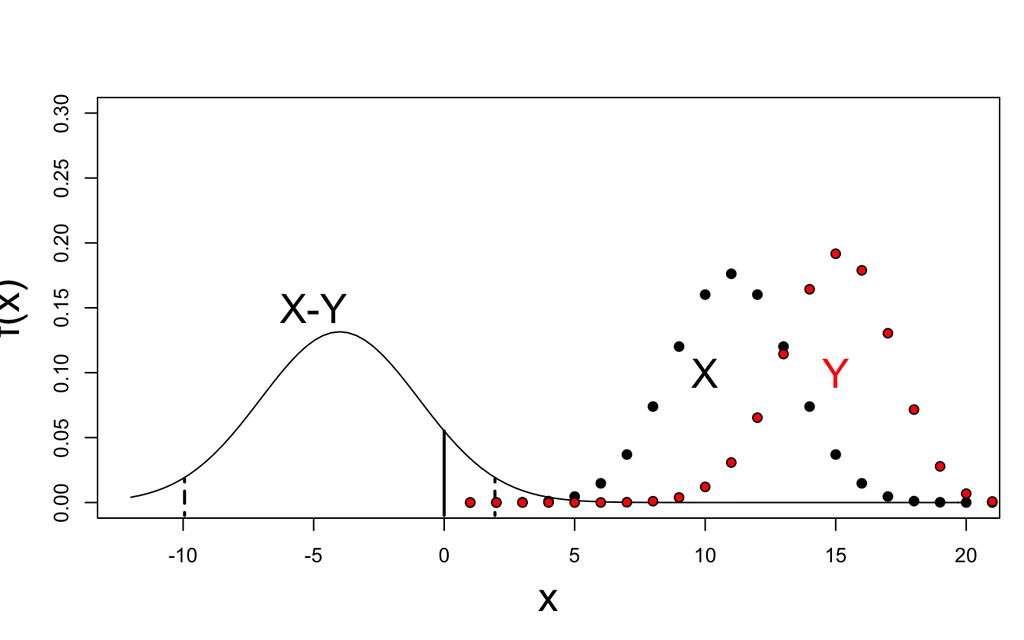

```r
par(mar=c(5,4,4,1))
curve(dnorm(x,p*n-q*m, sqrt( n*p*(1-p)+m*q*(1-q)) ),
      xlim=c(-12,20), ylim=c(0,0.3), ylab="f(x)", cex.lab=2)
segments(conf_int(0.05,n,p,m,q)[1],-0.01,
        conf_int(0.05,n,p,m,q)[1],
        dnorm(conf_int(0.05,n,p,m,q)[1],p*n-q*m,
              sqrt( n*p*(1-p)+m*q*(1-q)) ),
        col="black",lty=4, lwd=2)
segments(conf_int(0.05,n,p,m,q)[2],-0.01,
        conf_int(0.05,n,p,m,q)[2],
        dnorm(conf_int(0.05,n,p,m,q)[2],p*n-q*m,
              sqrt( n*p*(1-p)+m*q*(1-q)) ),
        col="black",lty=4, lwd=2)
segments(0, -0.01, 0, dnorm(0, p*n-q*m,
              sqrt( n*p*(1-p)+m*q*(1-q)) ), lwd=2 )
points(dbinom(0:n, n, p), pch=21, bg=1)
points(dbinom(0:m, m, q), pch=21, bg=2)
text(15, 0.1, "Y", cex=2, col=2)
text(10,0.1, "X", cex=2, col=1)
text(-5, 0.15, "X-Y", cex=2, col=1)
```

## Independent trials: weak law of large numbers

Consider the Bernoulli trials $X_{1}, \ldots, X_{n}$, with mean $p$ and variance $p(1-p)$. For this setting, the **weak law of large numbers** holds:

$$\overline{X}_n \overset{P}{\rightarrow} p, \ \mbox{as } n \rightarrow \infty,$$
where the notation $\overset{P}{\rightarrow}$ means convergence in probability.

```r
par(mar = c(4, 4, 0.5, 0.5),mfrow=c(1,1))
#I write the function depending on two arguments: n and p
law_large_numb<-function(n,p){
  x<-rbinom(n, 1,p)
  return(mean(x))
}
law_large_numb=Vectorize(law_large_numb)
```

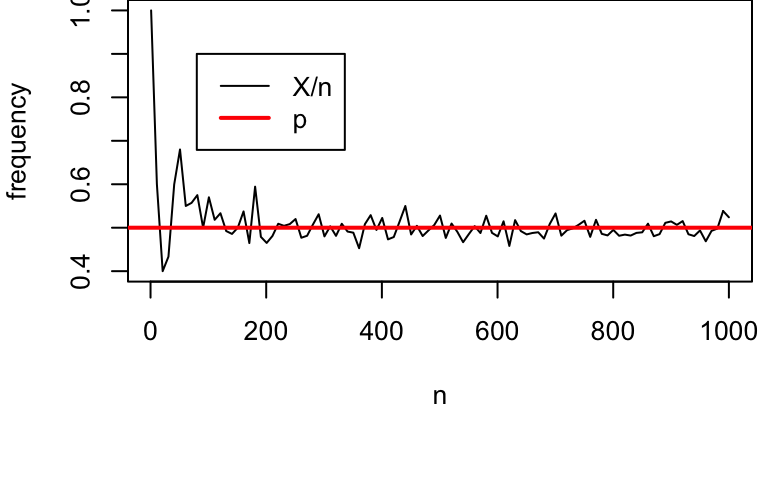

```r
set.seed(12345);par(mar = c(6.2, 4, 0, 0.5),mfrow=c(1,1))
curve(law_large_numb(x, p=0.5), 1,1000, xlab="n",
      ylab="frequency")
abline(a=0.5, b=0, lwd=2, col="red")
legend(80, 0.9, lty=1, col=c("black", "red"),
       lwd=c(1,2), c( "X/n", "p"))
```